# Iris species identification

Julian Störig

17.08.2020

## Data Description

The iris data-set contains 150 observation, divided into 50 observations each between three different species of iris flower, Iris setosa, Iris versicolor and Iris virginica.

For each observation it includes the length and width of the flowers sepal and petal leaves, along with the species name.

## Data Analysis

The data analysis for this report is done in R, this report written in reproducible R-Markdown, the source code for which is availiable [here](https://github.com/julianstoerig/data-analysis-and-templates/blob/master/learning/IrisSpeciesIdentificationReport.Rmd).

### scatter plots showing all indifidual data points

To get a general feel for the data, it is often advisable to take a look at all datapoints, find outliers and try to recognize trends, etc..

#### sepal leaves by species

[figure not shown]

#### petal leaves by species

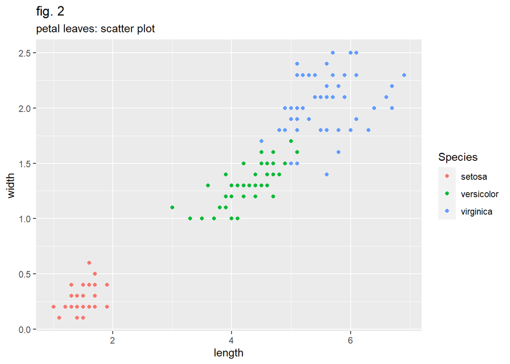